# Getting started in R with calculating screening values of mercury in fish

2025-06-23

This document contains some R code to get you started. We will walk through step by step how to use R for creating objects, data frames, and plots (and we will talk about what these are!). Our main focus is looking at how screening values for fish consumption depends on the size of a person and how often they are eating fish. The calculations used in this example can be found on the [FDA website](https://www.fda.gov/food/environmental-contaminants-food/technical-information-development-fdaepa-advice-about-eating-fish-those-who-might-become-or-are).

## Learning goals:

1. Identify the function name that loads packages
2. Recognize objects including variables, vectors, and data frames
3. Calculate values using mathematical operations and functions
4. Generate a scatterplot using ggplot2
5. Describe the relationships between body weight, weekly servings, and screening values (safe limits)

## Load package

“Packages” are computer code that someone wrote to do a particular thing. By loading a package, R downloads that code, so that you can do that thing yourself. Think of packages as tools for you to use in R that aren’t automatically part of R when you first installed it. The package below allows you to do more things in R, and makes coding much easier!

Below, we install the package “tidyverse” which we’ll use to organize data and to make pretty graphs. You only need to install a package once, but every time you use R you will have to load from the library using `library()`

```r
# if running for the first time, install the package
if(!require("tidyverse")) install.packages("tidyverse")
# every time you start R, load your package using library()
library(tidyverse)
```

## Getting screening value of mercury in fish

Start coding in the chunk below!

### Creating objects

```r
# define variables
weight = 150 # lbs

days_per_week = 2 # days per week eating fish

# example of using print function
print(weight)
```

```
## [1] 150
```

```r
print(days_per_week)
```

```
## [1] 2
```

```r
# example of checking the type of data
typeof(days_per_week)
```

```
## [1] "double"
```

### Use R for calculations - consumption rate and screening value

```r
# use our variables to calculate the mean daily consumption rate (cr)
# FDA reference amounts customarily consumed (RACC) per eating occasion for fish and shellfish without sauce is 110 grams for uncooked fish.
cr = 110*days_per_week/7 # daily consumption rate
print(cr)
```

```
## [1] 31.42857
```

```r
# calculate the safe limit screening value
# create another variable
RfD = 0.1 # ug mercurry/kg body weight/day

screening_value = RfD*weight*0.45/cr
print(screening_value)
```

```
## [1] 0.2147727
```

### Create a vector

```r
# make list
my_list <- list(100, "rachel", TRUE, 3.4)
# lists can contain mix of different data types

# make another list - vectors
weight_vector <- c(140, 175, 200, 220)
servings_per_week <- c(1, 7, 3, 4)
# vectors have the same type of data

print(weight_vector)
```

```
## [1] 140 175 200 220
```

```r
print(servings_per_week)
```

```
## [1] 1 7 3 4
```

```r
# can also reference a single location within a vector
weight_vector[1]
```

```
## [1] 140
```

### Create a data frame from vectors

```r
# create data frame with two columns - from the vectors weight, servings
sv_df <- data.frame(weight_vector, servings_per_week)

head(sv_df) # preview the entire data frame
```

```
##   weight_vector servings_per_week
## 1           140                 1
## 2           175                 7
## 3           200                 3
## 4           220                 4
```

```r
head(sv_df$weight_vector) # see the column weight
```

```
## [1] 140 175 200 220
```

```r
# Add column for screening value
sv_df$screen_val = RfD * sv_df$weight_vector * 0.45 / (110 * sv_df$servings_per_week / 7)

head(sv_df)
```

```
##   weight_vector servings_per_week screen_val
## 1           140                 1 0.40090909
## 2           175                 7 0.07159091
## 3           200                 3 0.19090909
## 4           220                 4 0.15750000
```

### Edit data frame

```r
# add a new column - use mutate
sv_df %>% mutate(cr = 110*servings_per_week/7)
```

```
##   weight_vector servings_per_week screen_val        cr
## 1           140                 1 0.40090909  15.71429
## 2           175                 7 0.07159091 110.00000
## 3           200                 3 0.19090909  47.14286
## 4           220                 4 0.15750000  62.85714
```

```r
# select only some columns
sv_df %>% select(servings_per_week, screen_val)
```

```
##   servings_per_week screen_val
## 1                 1 0.40090909
## 2                 7 0.07159091
## 3                 3 0.19090909
## 4                 4 0.15750000
```

```r
# filter out rows
sv_df %>% filter(weight_vector < 150)
```

```
##   weight_vector servings_per_week screen_val
## 1           140                 1  0.4009091
```

### Visualize data frame

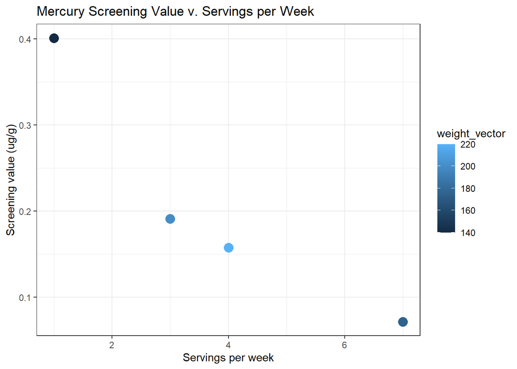

```r
# scaffold up to this plot
ggplot(data=sv_df,
      aes(x=servings_per_week, y=screen_val, col=weight_vector)) +
  geom_point(size=4) +
  theme_bw() +
  labs(x="Servings per week", y="Screening value (ug/g)",
       title="Mercury Screening Value v. Servings per Week")
```

### Read in data

```r
sv_df_long = read.csv("data/screening_values_per_week.csv")

# preview first 6 rows
head(sv_df_long)
```

```
##   weight serving_per_week screen_val
## 1    120                1 0.34363636
## 2    160                2 0.22909091
## 3    180                3 0.17181818
## 4    200                4 0.14318182
## 5    220                5 0.12600000
## 6    120                6 0.05727273
```

```r
# preview structure of data frame
str(sv_df_long)
```

```
## 'data.frame':    35 obs. of  3 variables:
##  $ weight          : int  120 160 180 200 220 120 160 180 200 220 ...
##  $ serving_per_week: int  1 2 3 4 5 6 7 1 2 3 ...
##  $ screen_val      : num  0.344 0.229 0.172 0.143 0.126 ...
```

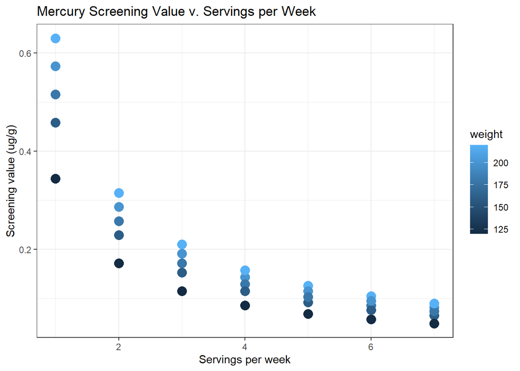

```r
ggplot(data=sv_df_long,
      aes(x=serving_per_week, y=screen_val, col=weight)) +
  geom_point(size=4) +
  theme_bw() +
  labs(x="Servings per week", y="Screening value (ug/g)",
       title="Mercury Screening Value v. Servings per Week")
```